# Supplementary

Katherine Silliman, Laura H Spencer, Steven Roberts

1/26/2022

## Supplementary

*Epigenetic and genetic population structure is coupled in a marine invertebrate*  
Katherine Silliman, Laura H Spencer, Steven B Roberts

#### Supplemental Figure 1

Frequency distribution of % methylation in *O. lurida* prior to filtering (left) and after filtering for loci with at minimum 5x coverage (right).

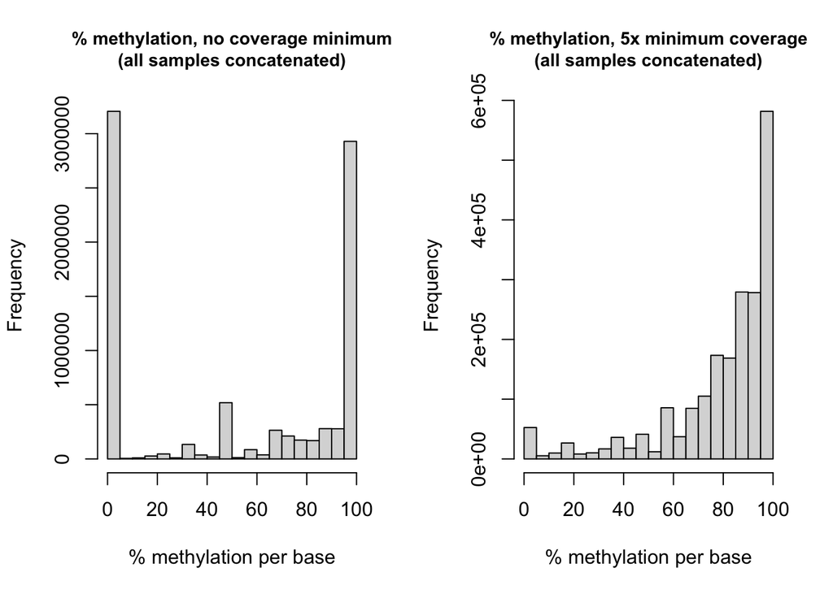

#### Supplemental Figure 2

Top: Table showing the % of all CpG loci and methylated loci that overlap with each genomic feature. Bottom: A correlation plot, showing residuals from chi-squared tests of homogeneity on the distribution of methylated loci and CpG loci that intersect with features. Blue=positive associations, red=negative associations, and size of circles represents the absolute value of each correlation coefficient.

| Feature | % of all CpGs in genome | % of all methylated loci | Ratio of % meth:%CpG |
| --- | --- | --- | --- |
| Exon | 3.99% | 14.71% | 3.69 |
| Intron | 13.94% | 19.76% | 1.42 |
| 5’ flanking region (-2kb) | 3.91% | 4.64% | 1.19 |
| 3’ flanking region (+2kb) | 3.92% | 4.66% | 1.19 |
| Transposable Elements | 14.93% | 13.83% | 0.93 |
| Unknown genome regions | 56.01% | 32.25% | 0.58 |

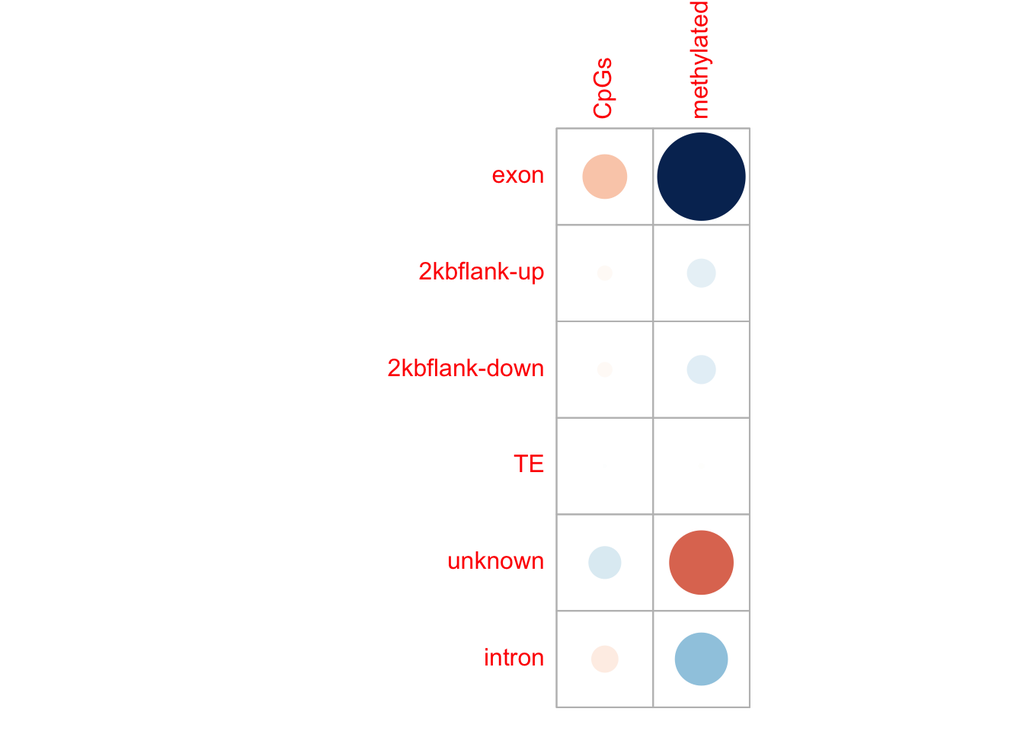

#### Supplemental Figure 3

Relative location of methylation within gene bodies in *Ostrea lurida*. For this analysis methylated loci were designated as those with >50% methylation when averaged across all MBD18 samples.

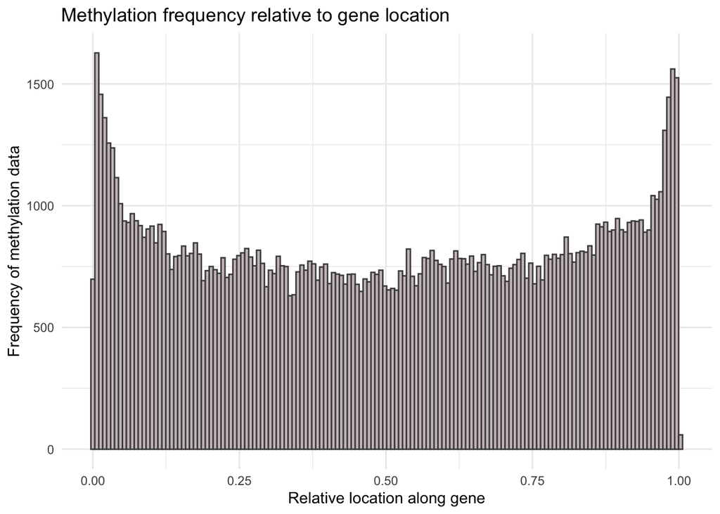

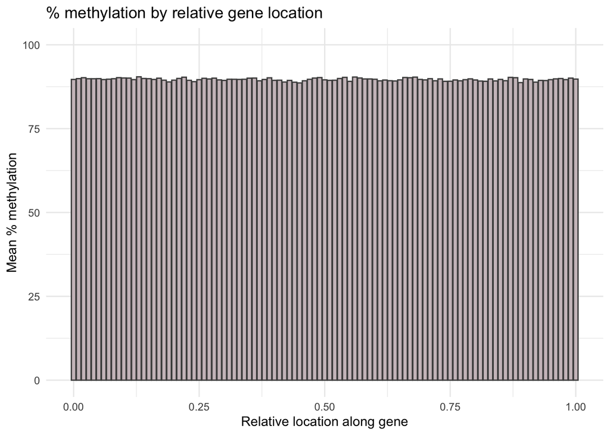

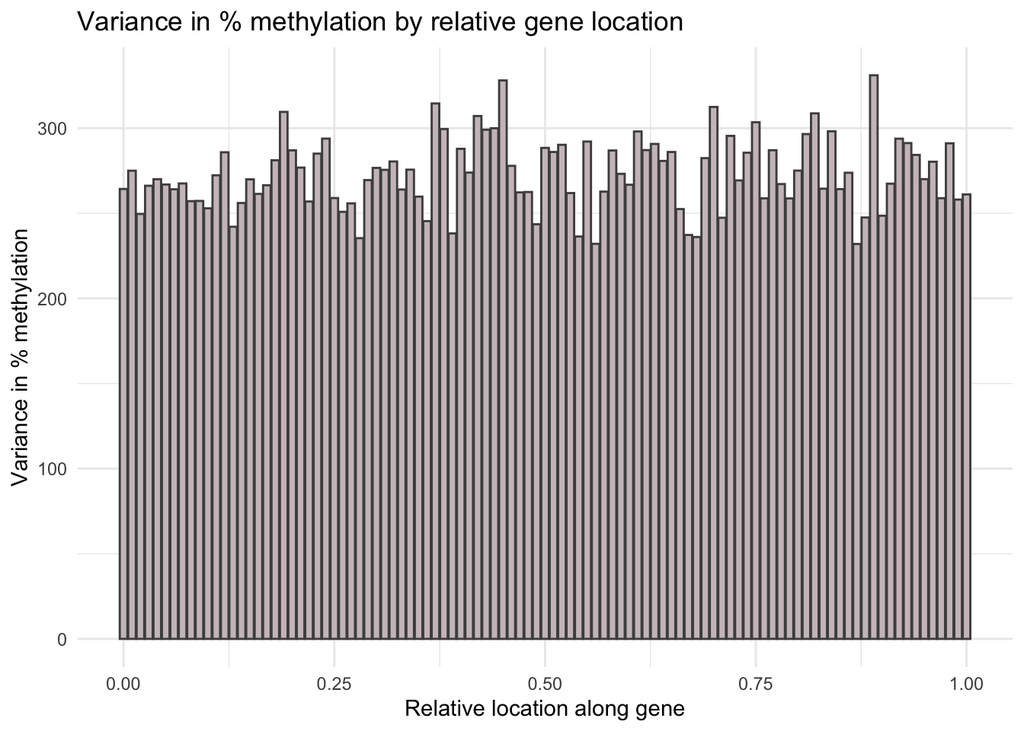

#### Supplemental Table 1

Biological functions that are enriched in the *Ostrea lurida* genome.

| GO Term | Biological Process | PValue | FDR | GO slim |
| --- | --- | --- | --- | --- |
| GO:0007067 | mitotic nuclear division | 0 | 0.37 | cell cycle and proliferation |
| GO:0007049 | cell cycle | 0 | 0.66 | cell cycle and proliferation |
| GO:0051321 | meiotic cell cycle | 0.05 | 1 | cell cycle and proliferation |
| GO:0000082 | G1/S transition of mitotic cell cycle | 0.07 | 1 | cell cycle and proliferation |
| GO:0000086 | G2/M transition of mitotic cell cycle | 0.09 | 1 | cell cycle and proliferation |
| GO:0007067 | mitotic nuclear division | 0 | 0.37 | cell organization and biogenesis |
| GO:0016569 | covalent chromatin modification | 0.01 | 1 | cell organization and biogenesis |
| GO:0060271 | cilium morphogenesis | 0.01 | 1 | cell organization and biogenesis |
| GO:0042384 | cilium assembly | 0.01 | 1 | cell organization and biogenesis |
| GO:0007030 | Golgi organization | 0.02 | 1 | cell organization and biogenesis |
| GO:0030030 | cell projection organization | 0.05 | 1 | cell organization and biogenesis |
| GO:0007005 | mitochondrion organization | 0.05 | 1 | cell organization and biogenesis |
| GO:0001822 | kidney development | 0.02 | 1 | developmental processes |
| GO:0001843 | neural tube closure | 0.07 | 1 | developmental processes |
| GO:0006281 | DNA repair | 0 | 0.08 | DNA metabolism |
| GO:0006260 | DNA replication | 0 | 0.37 | DNA metabolism |
| GO:0006310 | DNA recombination | 0.04 | 1 | DNA metabolism |
| GO:0006302 | double-strand break repair | 0.08 | 1 | DNA metabolism |
| GO:0006284 | base-excision repair | 0.09 | 1 | DNA metabolism |
| GO:0051301 | cell division | 0 | 0.12 | other biological processes |
| GO:0007018 | microtubule-based movement | 0.02 | 1 | other biological processes |
| GO:0042254 | ribosome biogenesis | 0.05 | 1 | other biological processes |
| GO:0016032 | viral process | 0.05 | 1 | other biological processes |
| GO:0043547 | positive regulation of GTPase activity | 0.05 | 1 | other biological processes |
| GO:0000910 | cytokinesis | 0.06 | 1 | other biological processes |
| GO:0032092 | positive regulation of protein binding | 0.08 | 1 | other biological processes |
| GO:0008104 | protein localization | 0.09 | 1 | other biological processes |
| GO:0031047 | gene silencing by RNA | 0.01 | 1 | other metabolic processes |
| GO:0006511 | ubiquitin-dependent protein catabolic process | 0 | 0.12 | protein metabolism |
| GO:0006412 | translation | 0 | 0.37 | protein metabolism |
| GO:0050821 | protein stabilization | 0.01 | 1 | protein metabolism |
| GO:0006468 | protein phosphorylation | 0.01 | 1 | protein metabolism |
| GO:0006413 | translational initiation | 0.03 | 1 | protein metabolism |
| GO:0000209 | protein polyubiquitination | 0.06 | 1 | protein metabolism |
| GO:0042787 | protein ubiquitination involved in ubiquitin-dependent protein catabolic process | 0.08 | 1 | protein metabolism |
| GO:0016567 | protein ubiquitination | 0.09 | 1 | protein metabolism |
| GO:0000398 | mRNA splicing, via spliceosome | 0 | 0.53 | RNA metabolism |
| GO:0006397 | mRNA processing | 0 | 1 | RNA metabolism |
| GO:0006364 | rRNA processing | 0.01 | 1 | RNA metabolism |
| GO:0006396 | RNA processing | 0.01 | 1 | RNA metabolism |
| GO:0008380 | RNA splicing | 0.02 | 1 | RNA metabolism |
| GO:0006366 | transcription from RNA polymerase II promoter | 0.05 | 1 | RNA metabolism |
| GO:0008033 | tRNA processing | 0.06 | 1 | RNA metabolism |
| GO:0006355 | regulation of transcription, DNA-templated | 0.09 | 1 | RNA metabolism |
| GO:0006974 | cellular response to DNA damage stimulus | 0 | 0.05 | stress response |
| GO:0006281 | DNA repair | 0 | 0.08 | stress response |
| GO:0006302 | double-strand break repair | 0.08 | 1 | stress response |
| GO:0006284 | base-excision repair | 0.09 | 1 | stress response |
| GO:0015031 | protein transport | 0 | 0.23 | transport |
| GO:0006886 | intracellular protein transport | 0 | 0.81 | transport |
| GO:0006888 | ER to Golgi vesicle-mediated transport | 0 | 0.96 | transport |
| GO:0016192 | vesicle-mediated transport | 0.02 | 1 | transport |
| GO:0006406 | mRNA export from nucleus | 0.04 | 1 | transport |
| GO:0006606 | protein import into nucleus | 0.09 | 1 | transport |
| GO:0042147 | retrograde transport, endosome to Golgi | 0.1 | 1 | transport |
| GO:0098609 | cell-cell adhesion | 0.04 | 1 | NA |
| GO:0070936 | protein K48-linked ubiquitination | 0.07 | 1 | NA |
| GO:0003341 | cilium movement | 0.07 | 1 | NA |

#### Supplemental Figure 4

Heat map of loci that are differentially methylated (DMLs) between the two populations.

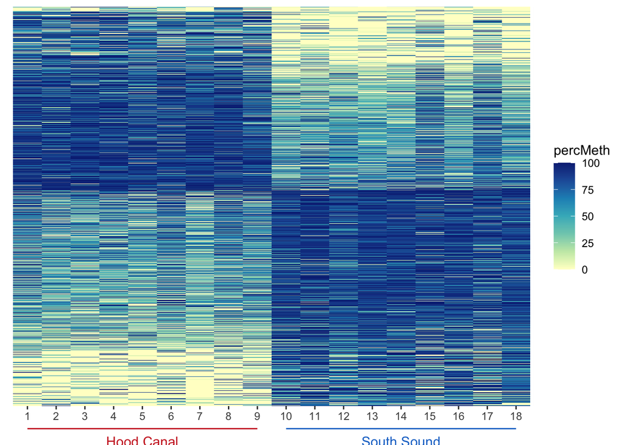

#### Supplemental Figure 5

PCA of methylation data using DMLs only

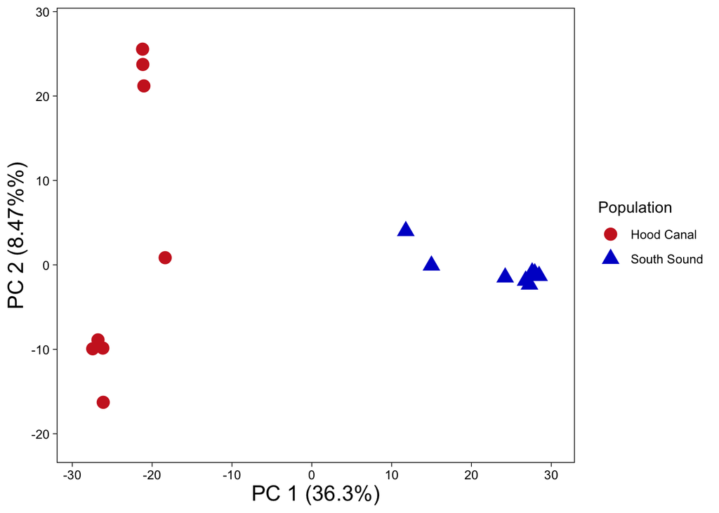

### Supplemental Figure 6

The % difference between each population’s mean methylation for differentially methylated loci, which highlights that both populations have a similar number of hyper/hypo-methylated loci. Loci are sorted by % methylation difference.

[figure not shown]

#### Supplemental Table 2

GO terms and GO Slim terms of biological functions enriched in DMGs & DMLs. EASE scores shown. FDR for all terms is 1.0.

| Go Slim | Term | Function | DMG | DML |
| --- | --- | --- | --- | --- |
| cell adhesion | GO:0007155 | cell adhesion | 0.012 |  |
| cell adhesion | GO:0007156 | homophilic cell adhesion via plasma membrane adhesion molecules | 0.026 | 0.00091 |
| cell adhesion | GO:0016339 | calcium-dependent cell-cell adhesion via plasma membrane cell adhesion molecules |  | 0.083 |
| cell organization and biogenesis | GO:0007015 | actin filament organization | 0.014 |  |
| cell organization and biogenesis | GO:0048675 | axon extension | 0.047 |  |
| cell organization and biogenesis | GO:0007411 | axon guidance | 0.063 |  |
| cell organization and biogenesis | GO:0000904 | cell morphogenesis involved in differentiation | 0.095 |  |
| cell organization and biogenesis | GO:0030198 | extracellular matrix organization | 0.033 |  |
| cell organization and biogenesis | GO:0032836 | glomerular basement membrane development | 0.046 |  |
| cell organization and biogenesis | GO:0007040 | lysosome organization | 0.047 |  |
| cell organization and biogenesis | GO:0031023 | microtubule organizing center organization | 0.095 |  |
| cell organization and biogenesis | GO:0051259 | protein oligomerization | 0.098 |  |
| cell organization and biogenesis | GO:0048841 | regulation of axon extension involved in axon guidance | 0.033 |  |
| cell organization and biogenesis | GO:0045214 | sarcomere organization | 0.069 | 0.019 |
| cell organization and biogenesis | GO:0055003 | cardiac myofibril assembly |  | 0.082 |
| cell organization and biogenesis | GO:0032438 | melanosome organization |  | 0.021 |
| cell organization and biogenesis | GO:0045332 | phospholipid translocation |  | 0.0058 |
| death | GO:0008625 | extrinsic apoptotic signaling pathway via death domain receptors | 0.095 |  |
| developmental processes | GO:0048675 | axon extension | 0.047 |  |
| developmental processes | GO:0007411 | axon guidance | 0.063 |  |
| developmental processes | GO:0032836 | glomerular basement membrane development | 0.046 |  |
| developmental processes | GO:0048841 | regulation of axon extension involved in axon guidance | 0.033 |  |
| developmental processes | GO:0045214 | sarcomere organization | 0.069 | 0.019 |
| developmental processes | GO:0007423 | sensory organ development | 0.095 |  |
| developmental processes | GO:0055003 | cardiac myofibril assembly |  | 0.082 |
| developmental processes | GO:0060429 | epithelium development |  | 0.071 |
| developmental processes | GO:0040027 | negative regulation of vulval development |  | 0.082 |
| developmental processes | GO:0021942 | radial glia guided migration of Purkinje cell |  | 0.082 |
| developmental processes | GO:0050767 | regulation of neurogenesis |  | 0.0058 |
| developmental processes | GO:0060438 | trachea development |  | 0.082 |
| developmental processes | GO:0001570 | vasculogenesis |  | 0.047 |
| other biological processes | GO:0016477 | cell migration | 0.029 | 0.032 |
| other biological processes | GO:0007281 | germ cell development | 0.048 |  |
| other biological processes | GO:0019915 | lipid storage | 0.043 |  |
| other biological processes | GO:0048477 | oogenesis | 0.046 |  |
| other biological processes | GO:0040008 | regulation of growth | 0.032 |  |
| other biological processes | GO:0042254 | ribosome biogenesis | 0.092 |  |
| other biological processes | GO:0019233 | sensory perception of pain | 0.016 |  |
| other biological processes | GO:0006879 | cellular iron ion homeostasis |  | 0.047 |
| other biological processes | GO:0050982 | detection of mechanical stimulus |  | 0.082 |
| other biological processes | GO:0050801 | ion homeostasis |  | 0.082 |
| other biological processes | GO:0007017 | microtubule-based process |  | 0.082 |
| other biological processes | GO:0032465 | regulation of cytokinesis |  | 0.057 |
| other biological processes | GO:0006941 | striated muscle contraction |  | 0.082 |
| other metabolic processes | GO:0042157 | lipoprotein metabolic process | 0.095 |  |
| other metabolic processes | GO:0010508 | positive regulation of autophagy | 0.063 |  |
| other metabolic processes | GO:0010923 | negative regulation of phosphatase activity |  | 0.028 |
| protein metabolism | GO:0031398 | positive regulation of protein ubiquitition | 0.098 | 0.093 |
| protein metabolism | GO:0016567 | protein ubiquitition |  | 0.0033 |
| protein metabolism | GO:0042787 | protein ubiquitition involved in ubiquitin-dependent protein catabolic process |  | 0.003 |
| signal transduction | GO:0046426 | negative regulation of JAK-STAT cascade |  | 0.071 |
| stress response | GO:0042594 | response to starvation |  | 0.03 |
| transport | GO:0006895 | Golgi to endosome transport | 0.043 | 0.019 |
| transport | GO:0034220 | ion transmembrane transport | 0.086 | 0.00049 |
| transport | GO:0008333 | endosome to lysosome transport |  | 0.083 |
| transport | GO:0045332 | phospholipid translocation |  | 0.0058 |
| NA | GO:0044331 | cell-cell adhesion mediated by cadherin | 0.033 | 0.071 |
| NA | GO:0072015 | glomerular visceral epithelial cell development | 0.095 |  |
| NA | GO:0086010 | membrane depolarization during action potential | 0.095 |  |
| NA | GO:1903955 | positive regulation of protein targeting to mitochondrion | 0.0082 |  |
| NA | GO:0038061 | NIK/NF-kappaB sigling |  | 0.071 |
| NA | GO:0090175 | regulation of establishment of plar polarity |  | 0.082 |